# R für Einsteiger: Musterlösungen

Kapitel 19: Lineare Strukturgleichungsmodelle

*Diese Musterlösung wurde erstellt von Peter Hähner (Ruhr-Universität Bochum).*

*(c) Luhmann: R fÃ¼r Einsteiger, 5. Aufl., Beltz, 2020*

## Vorbereitungen

Setzen Sie ein Arbeitsverzeichnis oder legen Sie ein entsprechendes R-Projekt an (Kap. 23).

Laden Sie dann die Datei `erstis.RData`.

```r
load("erstis.RData")
```

Laden Sie die benötigten Pakete (ggf. müssen Sie diese vorab noch installieren).

```r
library(lavaan)
library(semPlot)
```

## Aufgabe 1

Prüfen Sie, ob der Zusammenhang zwischen Lebenszufriedenheit (`lz.1`; abhängige Variable) und Neurotizismus (`neuro`) und Extraversion (`extra`) (Prädiktoren) jeweils durch die Stimmung (`gs.1`) vermittelt wird. Wählen Sie ein angemessenes Verfahren zur Prüfung des Mediationseffekts und fordern Sie auch standardisierte Koeffizienten an.

```r
# Modell spezifizieren
aufgabe.1 <- ' # a Pfade
              gs.1 ~ a1*neuro + a2*extra

               # b und c Pfade
              lz.1 ~ b*gs.1 + c1*neuro + c2*extra

               # Indirekte Effekte
              indNeuro := a1*b
              indExtra := a2*b

               # Totale Effekte
              totalNeuro := a1*b + c1
              totalExtra := a2*b + c2'

# Modell schÃ¤tzen
aufgabe.1.fit <- sem(aufgabe.1, data = erstis, se = "bootstrap")

# Unstandardisierte und standardisierte Koeffizienten ausgeben lassen
summary(aufgabe.1.fit, standardized = TRUE)
```

```
## lavaan 0.6-5 ended normally after 33 iterations
##
##   Estimator                                         ML
##   Optimization method                           NLMINB
##   Number of free parameters                          7
##
##                                                   Used       Total
##   Number of observations                           187         191
##
## Model Test User Model:
##
##   Test statistic                                 0.000
##   Degrees of freedom                                 0
##
## Parameter Estimates:
##
##   Standard errors                            Bootstrap
##   Number of requested bootstrap draws             1000
##   Number of successful bootstrap draws            1000
##
## Regressions:
##                    Estimate  Std.Err  z-value  P(>|z|)   Std.lv  Std.all
##   gs.1 ~
##     neuro     (a1)   -0.245    0.061   -4.034    0.000   -0.245   -0.298
##     extra     (a2)    0.179    0.071    2.514    0.012    0.179    0.188
##   lz.1 ~
##     gs.1       (b)    5.377    0.569    9.455    0.000    5.377    0.586
##     neuro     (c1)   -0.602    0.470   -1.280    0.200   -0.602   -0.080
##     extra     (c2)    0.836    0.496    1.686    0.092    0.836    0.096
##
## Variances:
##                    Estimate  Std.Err  z-value  P(>|z|)   Std.lv  Std.all
##    .gs.1              0.331    0.033    9.934    0.000    0.331    0.879
##    .lz.1             18.844    1.985    9.494    0.000   18.844    0.594
##
## Defined Parameters:
##                    Estimate  Std.Err  z-value  P(>|z|)   Std.lv  Std.all
##     indNeuro         -1.318    0.342   -3.856    0.000   -1.318   -0.174
##     indExtra          0.961    0.391    2.459    0.014    0.961    0.110
##     totalNeuro       -1.920    0.560   -3.426    0.001   -1.920   -0.254
##     totalExtra        1.796    0.639    2.811    0.005    1.796    0.206
```

```r
# Konfidenzintervall fÃ¼r indirekte Effekte ausgeben lassen
parameterEstimates(aufgabe.1.fit, ci = TRUE, boot.ci.type = "bca.simple")
```

```
##           lhs op     rhs      label    est    se      z pvalue ci.lower
## 1        gs.1  ~   neuro         a1 -0.245 0.061 -4.034  0.000   -0.373
## 2        gs.1  ~   extra         a2  0.179 0.071  2.514  0.012    0.034
## 3        lz.1  ~    gs.1          b  5.377 0.569  9.455  0.000    4.338
## 4        lz.1  ~   neuro         c1 -0.602 0.470 -1.280  0.200   -1.574
## 5        lz.1  ~   extra         c2  0.836 0.496  1.686  0.092   -0.242
## 6        gs.1 ~~    gs.1             0.331 0.033  9.934  0.000    0.273
## 7        lz.1 ~~    lz.1            18.844 1.985  9.494  0.000   15.602
## 8       neuro ~~   neuro             0.556 0.000     NA     NA    0.556
## 9       neuro ~~   extra             0.014 0.000     NA     NA    0.014
## 10      extra ~~   extra             0.415 0.000     NA     NA    0.415
## 11   indNeuro :=    a1*b   indNeuro -1.318 0.342 -3.856  0.000   -2.030
## 12   indExtra :=    a2*b   indExtra  0.961 0.391  2.459  0.014    0.184
## 13 totalNeuro := a1*b+c1 totalNeuro -1.920 0.560 -3.426  0.001   -2.977
## 14 totalExtra := a2*b+c2 totalExtra  1.796 0.639  2.811  0.005    0.440
##    ci.upper
## 1    -0.127
## 2     0.313
## 3     6.553
## 4     0.314
## 5     1.688
## 6     0.410
## 7    23.749
## 8     0.556
## 9     0.014
## 10    0.415
## 11   -0.692
## 12    1.751
## 13   -0.763
## 14    2.959
```

Beide indirekte Effekte sind signifikant, da der Wert 0 jeweils nicht im Konfidenzintervall enthalten ist.

## Aufgabe 2

Die Items `stim1`, `stim4`, `stim8` und `stim11` sollen jeweils die gute vs.Â schlechte Stimmung messen, wobei `stim4` und `stim11` negativ formuliert sind. PrÃ¼fen Sie, ob ein zweifaktorielles Modell, in dem die positiven und negativen Items auf unterschiedlichen Faktoren laden, besser passt als ein einfaktorielles Modell.

```r
# Einfaktorielles Modell spezifizieren und schÃ¤tzen
aufgabe.2a <- 'stimmung =~ stim1 + stim4 + stim8 + stim11'
aufgabe.2a.fit <- cfa(aufgabe.2a, data = erstis)

# Zweifaktorielles Modell spezifizieren und schÃ¤tzen
aufgabe.2b <- 'neg.Faktor =~ stim4 + stim11
               pos.Faktor =~ stim1 + stim8'
aufgabe.2b.fit <- cfa(aufgabe.2b, data = erstis)

# Fit-Statistiken und Modellparameter anfordern
summary(aufgabe.2a.fit, fit = TRUE)
```

```
## lavaan 0.6-5 ended normally after 17 iterations
##
##   Estimator                                         ML
##   Optimization method                           NLMINB
##   Number of free parameters                          8
##
##                                                   Used       Total
##   Number of observations                           188         191
##
## Model Test User Model:
##
##   Test statistic                                17.284
##   Degrees of freedom                                 2
##   P-value (Chi-square)                           0.000
##
## Model Test Baseline Model:
##
##   Test statistic                               227.047
##   Degrees of freedom                                 6
##   P-value                                        0.000
##
## User Model versus Baseline Model:
##
##   Comparative Fit Index (CFI)                    0.931
##   Tucker-Lewis Index (TLI)                       0.793
##
## Loglikelihood and Information Criteria:
##
##   Loglikelihood user model (H0)               -778.390
##   Loglikelihood unrestricted model (H1)       -769.748
##
##   Akaike (AIC)                                1572.780
##   Bayesian (BIC)                              1598.672
##   Sample-size adjusted Bayesian (BIC)         1573.332
##
## Root Mean Square Error of Approximation:
##
##   RMSEA                                          0.202
##   90 Percent confidence interval - lower         0.121
##   90 Percent confidence interval - upper         0.294
```

[output cut: 12 more lines]

```
## Latent Variables:
##                    Estimate  Std.Err  z-value  P(>|z|)
##   stimmung =~
##     stim1             1.000
##     stim4            -0.558    0.080   -6.958    0.000
##     stim8             0.887    0.098    9.019    0.000
##     stim11           -0.652    0.090   -7.280    0.000
##
## Variances:
##                    Estimate  Std.Err  z-value  P(>|z|)
##    .stim1             0.269    0.052    5.208    0.000
##    .stim4             0.341    0.039    8.696    0.000
##    .stim8             0.226    0.042    5.450    0.000
##    .stim11            0.407    0.048    8.546    0.000
##     stimmung          0.491    0.085    5.760    0.000
```

```r
summary(aufgabe.2b.fit, fit = TRUE)
```

```
## lavaan 0.6-5 ended normally after 22 iterations
##
##   Estimator                                         ML
##   Optimization method                           NLMINB
##   Number of free parameters                          9
##
##                                                   Used       Total
##   Number of observations                           188         191
##
## Model Test User Model:
##
##   Test statistic                                 1.758
##   Degrees of freedom                                 1
##   P-value (Chi-square)                           0.185
##
## Model Test Baseline Model:
##
##   Test statistic                               227.047
##   Degrees of freedom                                 6
##   P-value                                        0.000
##
## User Model versus Baseline Model:
##
##   Comparative Fit Index (CFI)                    0.997
##   Tucker-Lewis Index (TLI)                       0.979
##
## Loglikelihood and Information Criteria:
##
##   Loglikelihood user model (H0)               -770.627
##   Loglikelihood unrestricted model (H1)       -769.748
##
##   Akaike (AIC)                                1559.254
##   Bayesian (BIC)                              1588.382
##   Sample-size adjusted Bayesian (BIC)         1559.875
##
## Root Mean Square Error of Approximation:
##
##   RMSEA                                          0.064
##   90 Percent confidence interval - lower         0.000
##   90 Percent confidence interval - upper         0.217
```

[output cut: 19 more lines]

```
##     stim8             0.886    0.108    8.176    0.000
##
## Covariances:
##                    Estimate  Std.Err  z-value  P(>|z|)
##   neg.Faktor ~~
##     pos.Faktor       -0.253    0.047   -5.350    0.000
##
## Variances:
##                    Estimate  Std.Err  z-value  P(>|z|)
##    .stim4             0.263    0.042    6.222    0.000
##    .stim11            0.295    0.054    5.412    0.000
##    .stim1             0.249    0.059    4.201    0.000
##    .stim8             0.212    0.047    4.490    0.000
##     neg.Faktor        0.231    0.054    4.275    0.000
##     pos.Faktor        0.511    0.091    5.596    0.000
```

```r
# Modellvergleich
anova(aufgabe.2b.fit, aufgabe.2a.fit)
```

```
## Chi-Squared Difference Test
##
##                Df    AIC    BIC   Chisq Chisq diff Df diff Pr(>Chisq)
## aufgabe.2b.fit  1 1559.2 1588.4  1.7584
## aufgabe.2a.fit  2 1572.8 1598.7 17.2843     15.526       1  8.138e-05 ***
## ---
## Signif. codes:  0 '***' 0.001 '**' 0.01 '*' 0.05 '.' 0.1 ' ' 1
```

Das zweifaktorielle Modell passt signifikant besser als das einfaktorielle Modell (Ï<sup>2</sup>(1) = 15.53, *p* < .001).

## Aufgabe 3

Schätzen Sie ein Strukturgleichungsmodell, in dem die abhängige latente Variable `lz` (Lebenszufriedenheit, gemessen durch `lz13` , `lz14` und `lz15`) durch die unabhängigen latenten Variablen `gut` (gute Stimmung, gemessen durch `stim1` und `stim8`), `wach` (wache Stimmung, gemessen durch `stim2` und `stim10`) sowie `ruhig` (ruhige Stimmung, gemessen durch `stim6` und `stim12`) vorhergesagt wird. Stellen Sie das Strukturgleichungsmodell auch grafisch dar.

```r
# Modell spezifizieren
aufgabe.3 <- ' # Messmodelle
              lz =~ lz13 + lz14 + lz15
              gut =~ stim1 + stim8
              wach =~ stim2 + stim10
              ruhig =~ stim6 + stim12

               #Strukturmodell
              lz ~ gut + wach + ruhig'

# Modell schÃ¤tzen
aufgabe.3.fit <- sem(aufgabe.3, data = erstis)

# Fit-Statistiken und Modellparameter anfordern
summary(aufgabe.3.fit, fit = TRUE, standardized = TRUE)
```

```
## lavaan 0.6-5 ended normally after 39 iterations
##
##   Estimator                                         ML
##   Optimization method                           NLMINB
##   Number of free parameters                         24
##
##                                                   Used       Total
##   Number of observations                           187         191
##
## Model Test User Model:
##
##   Test statistic                                31.097
##   Degrees of freedom                                21
##   P-value (Chi-square)                           0.072
##
## Model Test Baseline Model:
##
##   Test statistic                               729.133
##   Degrees of freedom                                36
##   P-value                                        0.000
##
## User Model versus Baseline Model:
##
##   Comparative Fit Index (CFI)                    0.985
##   Tucker-Lewis Index (TLI)                       0.975
##
## Loglikelihood and Information Criteria:
##
##   Loglikelihood user model (H0)              -2085.792
##   Loglikelihood unrestricted model (H1)      -2070.243
##
##   Akaike (AIC)                                4219.584
##   Bayesian (BIC)                              4297.131
##   Sample-size adjusted Bayesian (BIC)         4221.113
##
## Root Mean Square Error of Approximation:
##
##   RMSEA                                          0.051
##   90 Percent confidence interval - lower         0.000
##   90 Percent confidence interval - upper         0.086
```

[output cut: 43 more lines]

```
## Variances:
##                    Estimate  Std.Err  z-value  P(>|z|)   Std.lv  Std.all
##    .lz13              0.500    0.085    5.899    0.000    0.500    0.269
##    .lz14              0.699    0.091    7.648    0.000    0.699    0.405
##    .lz15              0.501    0.074    6.750    0.000    0.501    0.325
##    .stim1             0.300    0.044    6.882    0.000    0.300    0.393
##    .stim8             0.170    0.034    4.970    0.000    0.170    0.277
##    .stim2             0.488    0.088    5.558    0.000    0.488    0.517
##    .stim10            0.491    0.073    6.696    0.000    0.491    0.594
##    .stim6             0.643    0.084    7.681    0.000    0.643    0.641
##    .stim12            0.045    0.122    0.369    0.712    0.045    0.050
##    .lz                0.436    0.115    3.777    0.000    0.321    0.321
##     gut               0.462    0.079    5.878    0.000    1.000    1.000
##     wach              0.456    0.110    4.139    0.000    1.000    1.000
##     ruhig             0.360    0.095    3.813    0.000    1.000    1.000
```

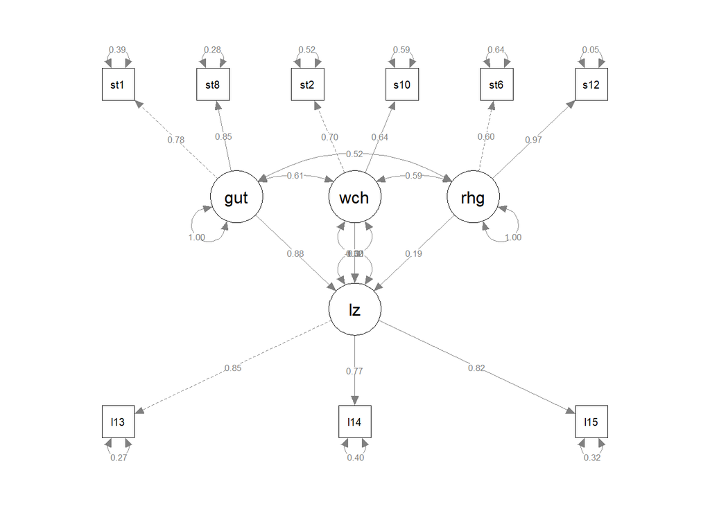

```r
# Grafische Darstellung (mit standardisierten Koeffizienten)
semPaths(aufgabe.3.fit, whatLabels = "standardized")
```